# A3: SPL Library Checkouts

### Introduction

For this assignment we were tasked with examining Seattle Public Library (SPL) data. The specific .csv data file I chose to analyze was collected by the SPL “includ[ing] a monthly count of Seattle Public Library checkouts by title for physical and electronic items” spanning from 2013 to 2023. Using this data set I specifically decided to take a look at the effect COVID-19 had on SPL checkouts. I examined the various different types of medias that can be checked out from the library; how the check out rate has fluctuated for each media over the past 10 years – observing drastic changes in recent times during the COVID-19 pandemic. Along with that, I more specifically took a closer look at the year 2020; the defining year of the pandemic. For the year 2020, I analyzed more specific statistics including the leading creators at the SPL in 2020, subjects, and more.

I chose to focus on 2020 and the effects of COVID-19 in relation to the SPL because I was compelled to learn about more local impacts of the pandemic. Everything we saw on the news in the year 2020 was about COVID-19 cases and deaths, people having to work from home, and school cancellations. The effects the pandemic had on library checkouts is not exactly the first thing I think of when I think about the effects of the pandemic, so i was excited to learn more.

### The Dataset

The Seattle Public Library data set that I am analyzing for the purposes of this assignment can be found on the “Seattle Open Data” program website. The Open Data program makes it possible for data collected and generated by the City of Seattle to be publicly available. This specific data set was collected from multiple sources. In terms of Digital Items, media vendors: Overdrive, hoopla, Freegal, and RBDigital are the source of the provided usage data. For physical “item checkouts from April 2005 to September 30, 2016, the source of this data is the Legrady artwork data archives[, and for] For October 1 2016 to present, the source is the Horizon ILS.” One can assume that this data was collected to keep track of item/material inventory or generate an economic opportunity for those that may benefit from the knowledge created the data. Though, there was no clear indicator as to why this data set was made publicly available.

When working with data sets as large as this, it can become important to filter and narrow down the specific data you are looking for. The data set I was working with spanned about 10 years and had over 4 million entries, each comprised of 12 columns. Additionally, it must be kept in mind when looking through my graphs and calculations that the specific data set I looked at only included items that were checked out at least 5 times a month.

Sorting through this data was difficult as not all of the information was inputted the same, or spelled correctly. When filtering through the book subjects there were more that 225,000 different subjects I had to narrow down, and when looking through some of the book titles it could be observed that there were multiple entries for the same book because it had been misspelled.

Regardless of how difficult the data set size may make it to interpret, taking a second to realize the scope at which this data was collected is amazing and super cool. Lastly, in terms of ethical questions in regard to this data, I see no problem. The nature of this data being absent of any human actions removes any ethical concerns.

### First Trends Over Time Chart

My first chart shows the trend over time of how many normal books, eBooks, and audio books were checked out each year from 2013 to 2022. I decided to create this chart as I was curious if COVID-19 would have any sort of impact on these rates. As can be seen, in the year 2020, which was the defining year of the COVID-19 pandemic regular book checkout rates took a massive dive. One can infer that this occurred because most public places were somewhat inaccessible during the pandemic. It can also be observed that both eBooks and audio books were unaffected by this in 2020, as their checkout rates continued to climb compared to the previous year 2019.

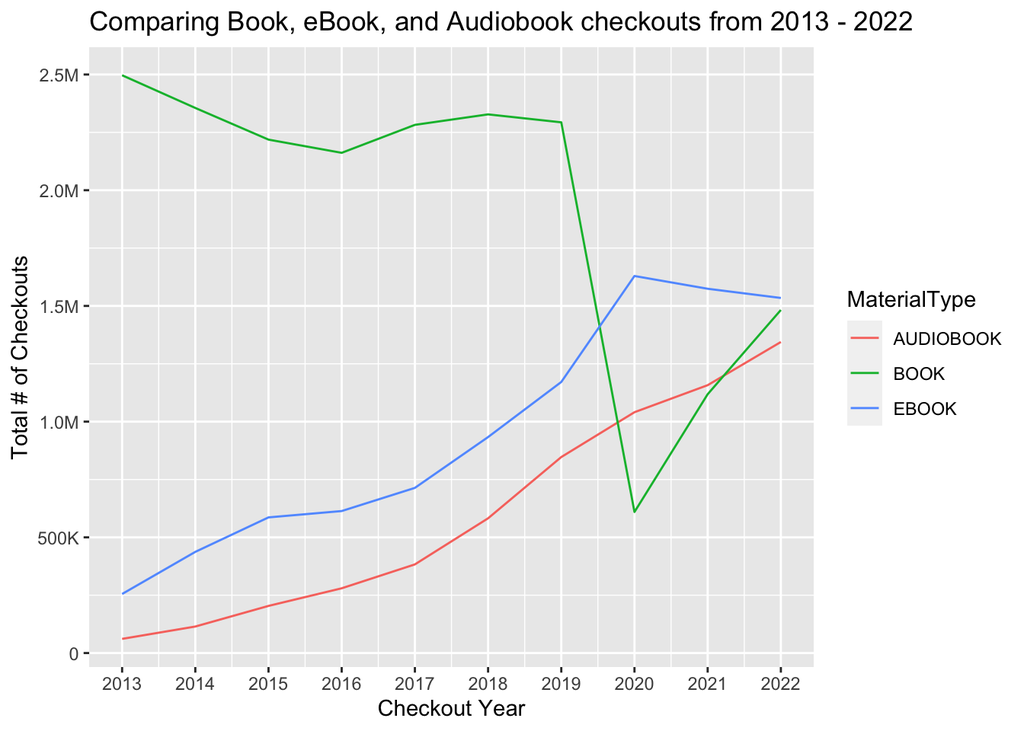

### Second Trends Over Time Chart

My second chart shows the trend over time of the most popular authors in the year 2020. I decided to take a closer look at authors in the specific year 2020 because of the checkout dip that took place in the year 2020 as seen in the previous graph, and I wanted to see how this would affect what authors were most popular. Taking a look at what types of novels each of these authors write patterns can be established. The first couple months of the year it can be analyzed that the most popular novels are cartoons, though, when transitioning into the middle of the year when the black lives matters protest/movement was at a all time high, creators who wrote about racial injustice became more popular. Then again, in the later months of the year audiences turned more towards creators who wrote fiction such as J.K. Rowling who was the most popular author in 2020.

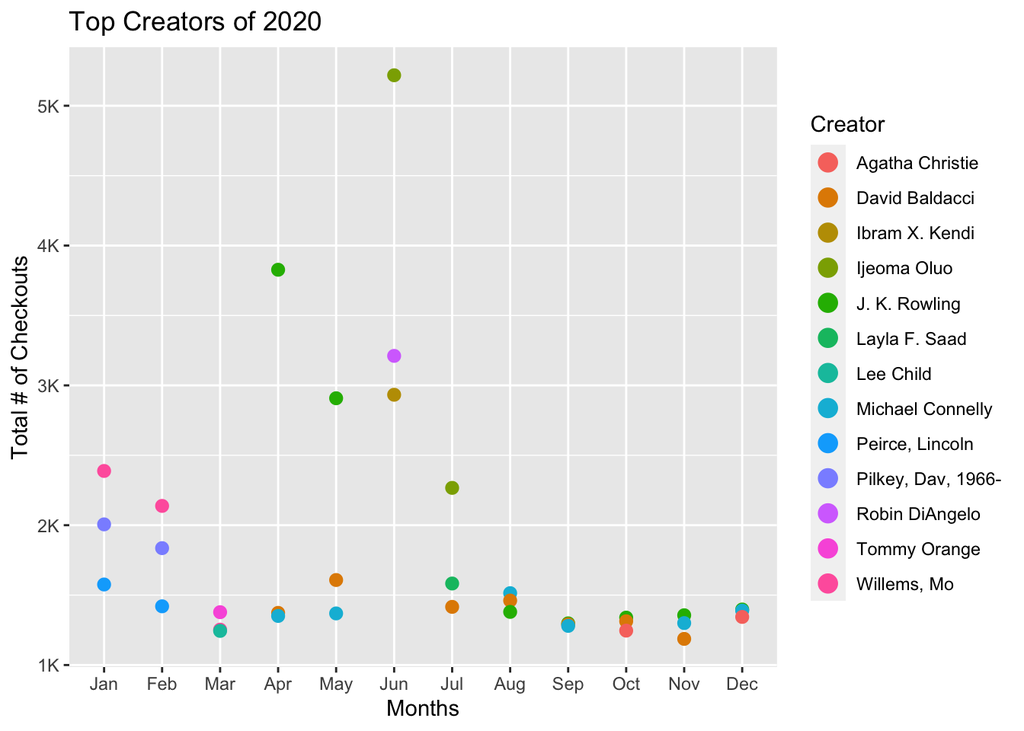

### Your Choice

For my last chart I decided to take a look at the top subjects in 2020, going hand in hand with my top creators of 2020 graph. As you can see Fiction was by far the most checked out subject with more than 3 times as many checkouts as the second most popular subject which was fantasy… which did more surprise me. Though, what did stand out to me were the subjects ranked 9 & 10: African American Nonfiction and African American fiction. Again, it can be assumed that this is because the year 2020 is when the height of the Black Lives Matter protests took place.

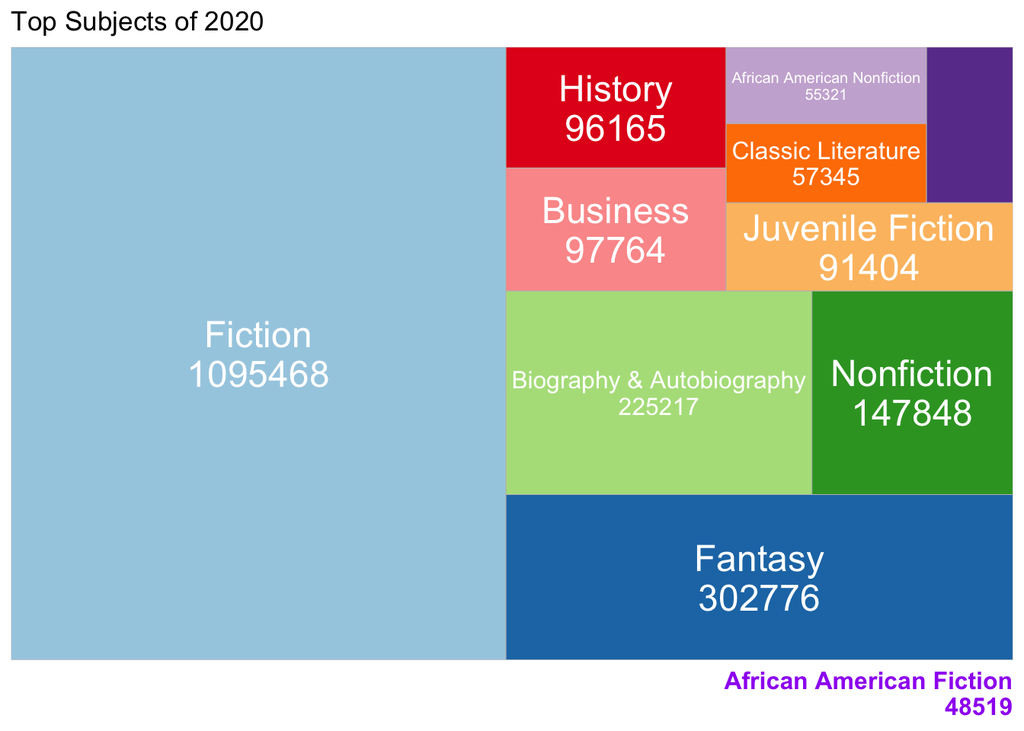